```python
from sklearn.metrics import silhouette_score,silhouette_samples
from yellowbrick.cluster import SilhouetteVisualizer

import numpy as np
import matplotlib.pyplot as plt
from sklearn.cluster import KMeans

import librosa as lb
import os
import tqdm

from sklearn.decomposition import PCA
from imblearn.over_sampling import SMOTE
```

```python
from google.colab import drive
drive.mount('/content/drive')
```

Andreu Cantó y Amparo Gálvez

# Introducción

Se proporcionan algunos audios con diferentes características cada uno, en ellos se pueden escuchar distintas cosas, aunque en no se proporciona información al respecto. Si bien podríamos escuchar cada uno de los audios para tener una etiqueta, esto es inviable al tener una cantidad grande de audios, tu tarea es intentar averiguar cuántos elementos distintos aparecen en el dataset utilizando K-means y todo lo aprendido en la parte 1 de esta práctica.

Hasta ahora en las prácticas hemos visto cómo trabajar con datos tabulares, donde cada muestra tiene un vector de características que lo define, en el caso de audio, esto no es posible, pero una forma usual de procesar este tipo de datos es calculando un espectrograma, el cual pasa del dominio del tiempo/amplitud una señal de audio al dominio de frecuencia/tiempo (puedes ver la implementación en este cuaderno), donde para nuestro ejemplo cada valor de frecuencia calculada será una característica que define al audio. Si bien este tema escapa de los alcances de la asignatura puedes ver mas informacion en https://librosa.org/doc/main/generated/librosa.feature.melspectrogram.html

Notas:

- Comienza con un análisis y una descripción de los datos con los que se cuenta (la sección del código que carga los audios ya está implementada).
- Intenta probar de manera sistemática diferentes parámetros (no olvides comentar tu código y trata de mantener en el cuaderno toda la información).
- Silhouette score y Elbow Curve te pueden ayudar a justificar tus conclusiones.
- Una forma de representar los datos con una alta dimensionalidad es utilizando PCA, usa `sklearn.decomposition.PCA`, para obtener una representación de menor dimensionalidad de los datos de entrada.
- Si bien, escuchar todos los audios no es posible o toma mucho tiempo, si puedes escuchar algunos para ayudarte a justificar tus conclusiones.
- En este mismo cuaderno haz un reporte con tus hallazgos y conclusiones, soporta todo lo que comentas.

```python
data_folder="sample_data/audios/"
files=os.listdir(data_folder)

datos=[]
for name in tqdm.tqdm(files):
  audio,sr=lb.load(data_folder+name,sr=16000,mono=True)
  audio=lb.util.normalize(audio)
  X = np.abs(lb.stft(audio, n_fft=2048, hop_length=256, win_length=2048, window='hamming', center=True))
  mel = lb.feature.melspectrogram(sr=16000, S=X, n_fft=2048, hop_length=256, power=1.0,
                                        n_mels=64, fmin=0, fmax=8000, htk=True, norm=None)
  features=np.mean(mel,axis=1)
  features=features/features.max()
  datos.append(features)
datos=np.array(datos)
```

```
  warnings.warn(
```

Puedes usar la celda siguiente para hacer tu reporte, te dejamos una posible plantilla aunque este apartado es libre. El texto en azul lo puedes eliminar.

```python
len(datos[2])
```

```
64
```

# Reporte de practica

**Descripcion de datos**

Contamos con 108 audios, cada uno representado por un vector de 64 dimensiones extraido apartir del espectograma de Mel, el cual es una representacion en el dominio de la frecuencia de nuestra señal de entrada.

El primer paso será observar la curva de Elbow y dibujamos la Silhouette de cada división para intentar apreciar algun indicador que nos permita decidir el número de clusters en el que queremos dividir nuestros datos.

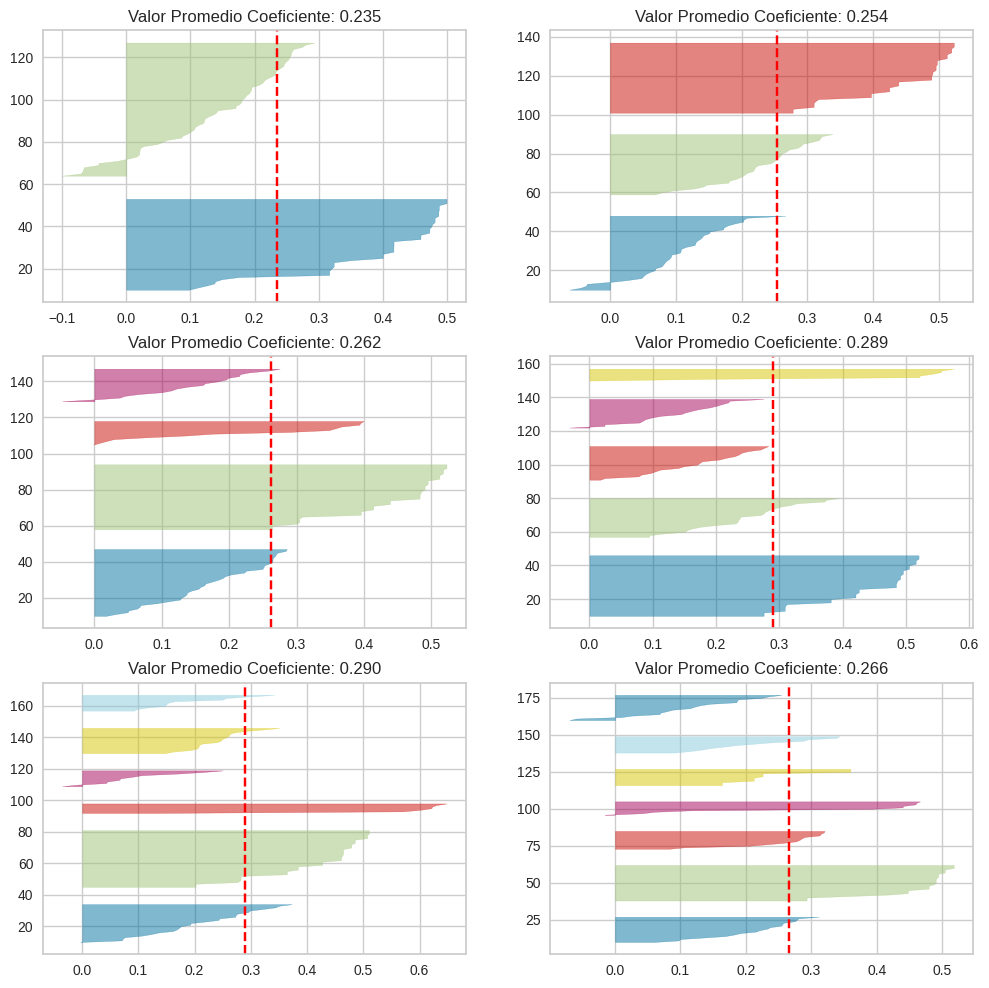

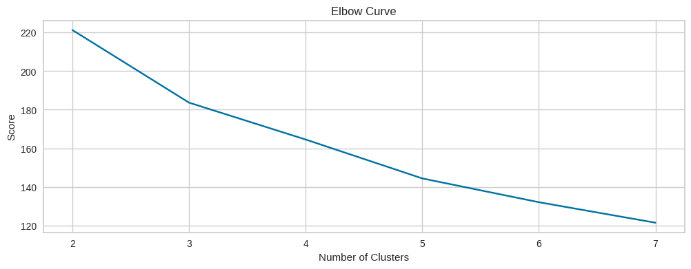

```python
#Dataset 2

#Seleccionamos un rango de clusters a analizar
n_clusters=[2, 3, 4, 5, 6, 7]

fig, ax = plt.subplots(3, 2, figsize=(12,12))
scores=[]
for c in n_clusters:
    #definimos el metodo KMeans
    km = KMeans(n_clusters=c, init='k-means++', n_init=10, random_state=123)
    q, mod = divmod(c, 2)
    km.fit(datos)

    #recolectamos en un vector los valores de inertia
    scores.append(km.inertia_)

    #calculamos el silhouette score y mostramos su grafica
    score = silhouette_score(datos, km.labels_, metric='euclidean')
    visualizer = SilhouetteVisualizer(km, colors='yellowbrick', ax=ax[q-1][mod])
    leyenda= "Valor Promedio Coeficiente: %.3f" % (score)
    visualizer.set_title(leyenda)
    visualizer.fit(datos)
plt.show()

#Graficamos los valores de inertia para cada numero de cluster
plt.figure(figsize=(12,4))
plt.xlabel('Number of Clusters')
plt.ylabel('Score')
plt.title('Elbow Curve')
plt.plot(n_clusters,scores)
plt.show()
```

**Análisis**

Las dos posibles divisiones por las que nos vamos decantar es entre 2 y 3 clusters. Un número mas elevado de clústers parece que divide clústeres en subclústeres y unir en 2 clusters no parece adecuado debido a su bajo coeficiente.

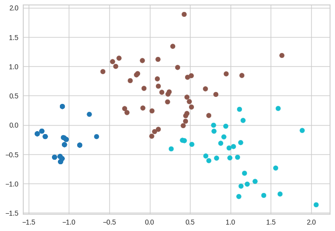

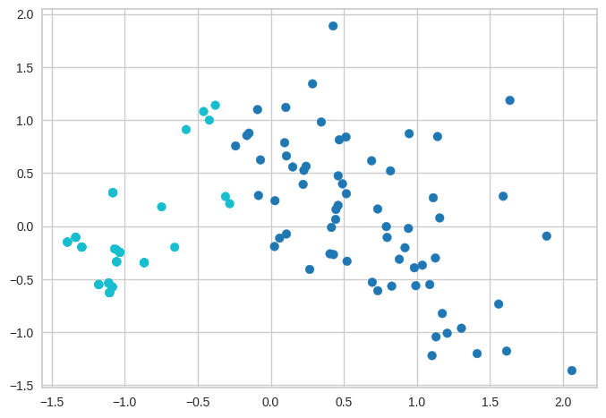

```python
pca = PCA(n_components=2)
X_pca = pca.fit_transform(datos)
#print(X_pca[:,0])

y = KMeans(n_clusters=3, random_state=123, init='random').fit_predict(X_pca)
plt.scatter(X_pca[:, 0], X_pca[:, 1], c=y, cmap="tab10")
plt.show()

y = KMeans(n_clusters=2, random_state=123, init='random').fit_predict(X_pca)
plt.scatter(X_pca[:, 0], X_pca[:, 1], c=y, cmap="tab10")
plt.show()
```

**Resultados**

**Conclusiones**

El resultado final del análisis nos divide los datos en 3 clusters que al comprobar los audios vemos que divide entre sonidos de sirenas, de tonos de movil y de claxons.